# Solucion 12: correlacion con datos nativos y correlograma

Instructor

## 1. `mtcars`: matriz de correlacion

```r
cor_mtcars <- cor(mtcars)
round(cor_mtcars, 2)
```

```
##        mpg   cyl  disp    hp  drat    wt  qsec    vs    am  gear  carb
## mpg   1.00 -0.85 -0.85 -0.78  0.68 -0.87  0.42  0.66  0.60  0.48 -0.55
## cyl  -0.85  1.00  0.90  0.83 -0.70  0.78 -0.59 -0.81 -0.52 -0.49  0.53
## disp -0.85  0.90  1.00  0.79 -0.71  0.89 -0.43 -0.71 -0.59 -0.56  0.39
## hp   -0.78  0.83  0.79  1.00 -0.45  0.66 -0.71 -0.72 -0.24 -0.13  0.75
## drat  0.68 -0.70 -0.71 -0.45  1.00 -0.71  0.09  0.44  0.71  0.70 -0.09
## wt   -0.87  0.78  0.89  0.66 -0.71  1.00 -0.17 -0.55 -0.69 -0.58  0.43
## qsec  0.42 -0.59 -0.43 -0.71  0.09 -0.17  1.00  0.74 -0.23 -0.21 -0.66
## vs    0.66 -0.81 -0.71 -0.72  0.44 -0.55  0.74  1.00  0.17  0.21 -0.57
## am    0.60 -0.52 -0.59 -0.24  0.71 -0.69 -0.23  0.17  1.00  0.79  0.06
## gear  0.48 -0.49 -0.56 -0.13  0.70 -0.58 -0.21  0.21  0.79  1.00  0.27
## carb -0.55  0.53  0.39  0.75 -0.09  0.43 -0.66 -0.57  0.06  0.27  1.00
```

## 2. Correlacion negativa: `mpg` y `wt`

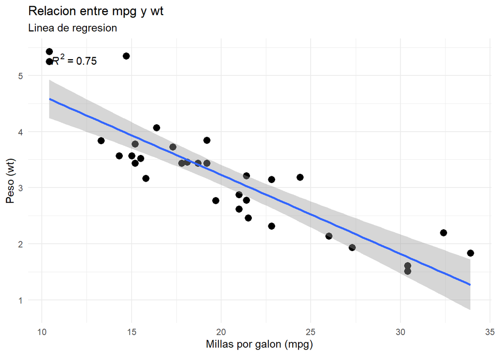

```r
library(ggpmisc)

ggplot(mtcars, aes(x = mpg, y = wt)) +
  geom_point(size = 3) +
  geom_smooth(method = "lm") +
  stat_poly_eq() +
  labs(title = "Relacion entre mpg y wt",
       subtitle = "Linea de regresion",
       x = "Millas por galon (mpg)", y = "Peso (wt)") +
  theme_minimal()
```

**Interpretacion:** la relacion es negativa: los autos mas pesados rinden menos millas por galon. Tiene sentido fisico: un auto mas pesado requiere mas energia para moverse. El R2 del grafico es el coeficiente de determinacion de la recta de regresion e indica que proporcion de la variacion de `wt` explica `mpg`.

## 3. Correlograma de `mtcars`

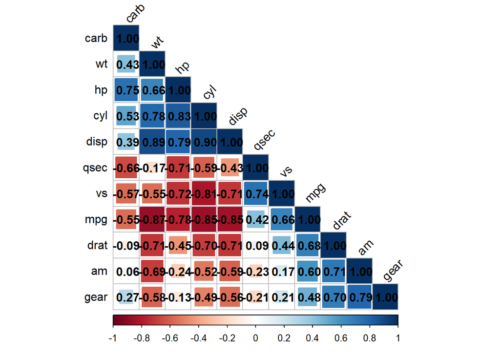

```r
corrplot(cor_mtcars, method = "square", type = "lower",
         order = "hclust", tl.col = "black", tl.srt = 45,
         addCoef.col = TRUE)
```

**Interpretacion:** las correlaciones positivas se muestran en azul y las negativas en rojo; el tamano del cuadrado es proporcional al coeficiente.

## 4. Otros conjuntos de datos

```r
air_tidy <- na.omit(airquality)
round(cor(air_tidy), 2)
```

```
##         Ozone Solar.R  Wind  Temp Month   Day
## Ozone    1.00    0.35 -0.61  0.70  0.14 -0.01
## Solar.R  0.35    1.00 -0.13  0.29 -0.07 -0.06
## Wind    -0.61   -0.13  1.00 -0.50 -0.19  0.05
## Temp     0.70    0.29 -0.50  1.00  0.40 -0.10
## Month    0.14   -0.07 -0.19  0.40  1.00 -0.01
## Day     -0.01   -0.06  0.05 -0.10 -0.01  1.00
```

```r
round(cor(USArrests), 2)
```

```
##          Murder Assault UrbanPop Rape
## Murder     1.00    0.80     0.07 0.56
## Assault    0.80    1.00     0.26 0.67
## UrbanPop   0.07    0.26     1.00 0.41
## Rape       0.56    0.67     0.41 1.00
```

**Interpretacion:**

- En `airquality`, la variable mas relacionada con el ozono (`Ozone`) es la temperatura (`Temp`, 0,70), seguida de la velocidad del viento (`Wind`, -0,61).
- En `USArrests`, `UrbanPop` y `Murder` tienen una correlacion debil (0,07): el grado de urbanizacion no explica por si solo los asesinatos. La correlacion mas fuerte es entre `Murder` y `Assault` (0,80).